# Advanced Topic Assignment

Clara Buchholtz

3/29/2020

## Introduction

Advanced topics focus: Spatial Stats, Point Patterns, Nearest Neighbors

My current research is focused on biodiversity loss, and understanding how cumulative impacts (often a combination of life history and external environmental factors) can cause local extinctions. My project centers around a local threatened endemic plant, Mulford’s milkvetch (Astragalus mulfordiae). This plant has a limited range, and is only known to grow in three areas: the Boise Foothills, the Owyhee Front, and Washington County Idaho near Weiser. The known threats to A. mulfordiae include grazing, increasing fire frequency, agriculture and urbanization, invasive annual grasses, and motorized recreation. With the growing population in the Treasure Valley, recreation levels (especially OHV use) have increased, but very little data exists on the patterns and spatial extent of the impacts. In an effort to fill this knowledge gap, part of my research includes working with the BLM Bruneau Field office to map baseline recreation disturbance levels near subpopulations of Mulford’s milkevetch. These sites are ideal for further study of recreation impacts because the milkvetch populations have been monitored for decades, and long term data on their status, as well as other nearby plant, human, and animal disturbances exist.

The goal of my collaboration with the BLM will be to produce actionable products, such as maps and datasets that can inform management decisions. One of the ways a point pattern analysis could be used to this end would be to identify clusters of disturbance points, and use this to examine if something can explain why such a clustering might exist.

## Pseudocode

```r
#First, load in the libraries used:
library(spatstat)
library(sf)
library(rgdal)
library(rgeos)
library(ggplot2)
library(maptools)
library(profvis)
library(tidyverse)
library(here)
library(googledrive)
library(curl)


#Connect to Google Drive
folder_url <- "https://drive.google.com/drive/folders/1aahpoWXewhoVEdng8alreewHg81Ms3p7?usp=sharing"
folder <- drive_get(as_id(folder_url))
gdrive_files <- drive_ls(folder)
lapply(gdrive_files$id, function(x) drive_download(as_id(x),
                                                   path = paste0(here::here("datatemp/original/"), gdrive_files[gdrive_files$id==x,]$name), overwrite = TRUE))
```

## Loading in data: Simulated Data

I’ll be working with simulated point data to demonstrate some point pattern analyses. In order to do this, I’ll create a plot with points within it, and then use spatial tests to investigate point patterns.

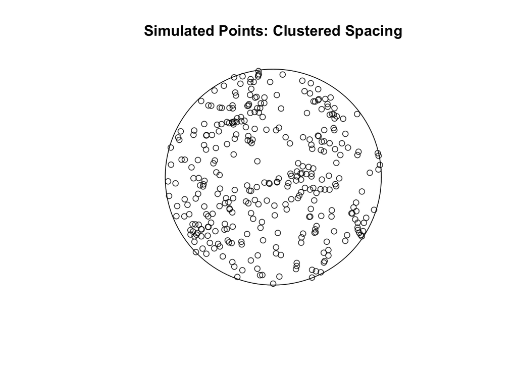

```r
#-------Simulated Data--------#

#enerating x number of RANDOM points in a circle
# Create n points in a circle of a chosen radius:
n_points <- 300
radius <- 10

# Create uniform random numbers up to radius-squared:
r_squared <- runif(n_points, 0, radius^2)
angle <- runif(n_points, 0, 2*pi)

#Get a uniform spatial distribution by taking the square root of the values:
xx <- sqrt(r_squared)* cos(angle)
yy <- sqrt(r_squared) * sin(angle)

#View the output:
#plot(disc(radius)); points(xx, yy)

#generating x number of CLUSTERED points in a circle
# Create a disc of radius 10, for the window space
disc10 <- disc(10)

# Generate clustered points from a Thomas process
set.seed(123)
p_cluster <- rThomas(kappa = 0.35, scale = 1, mu = 3, win = disc10)
plot(p_cluster, main= "Simulated Points: Clustered Spacing")
```

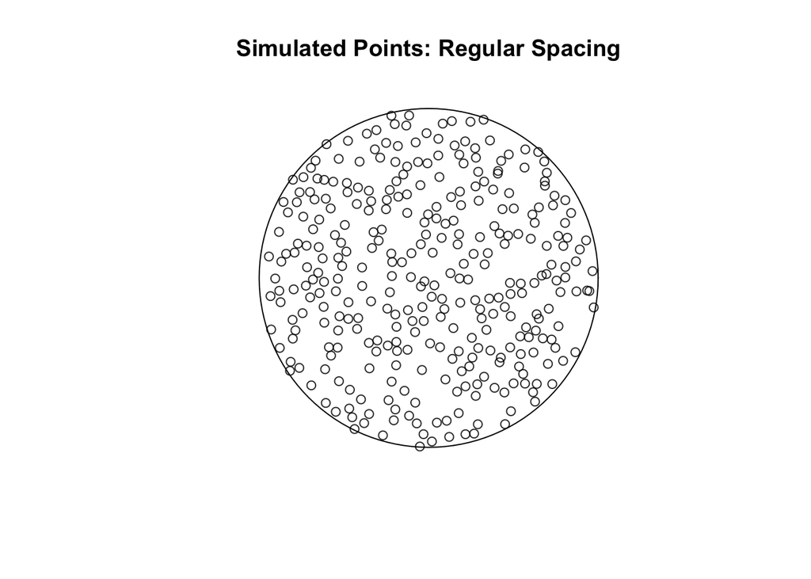

```r
#generating x number of REGULAR points (aka a repulsive point pattern) in a circle
set.seed(123)
p_regular <- rStrauss(beta = 2.9, gamma = 0.025, R = .5, W = disc10)
plot(p_regular, main="Simulated Points: Regular Spacing")
```

## Loading in data: Sample Data

I’ll also bring in and test sample data I’ve made in Google Earth (and then converted to a shapefile) of points where informal trails branch off of established trails and roads. These points are from an area within a 1 mile radius of one of the Mulford’s milkvetch populations in the Owyhee Front.

```r
#Read in data
InfTrailsAll <- st_read("/Users/Clara/Dropbox/Coursework/Spring_2020/Spatial_Data_in_R/Clara_HES598/datatemp/original/InfTrailPoints_SpatR.shp")
```

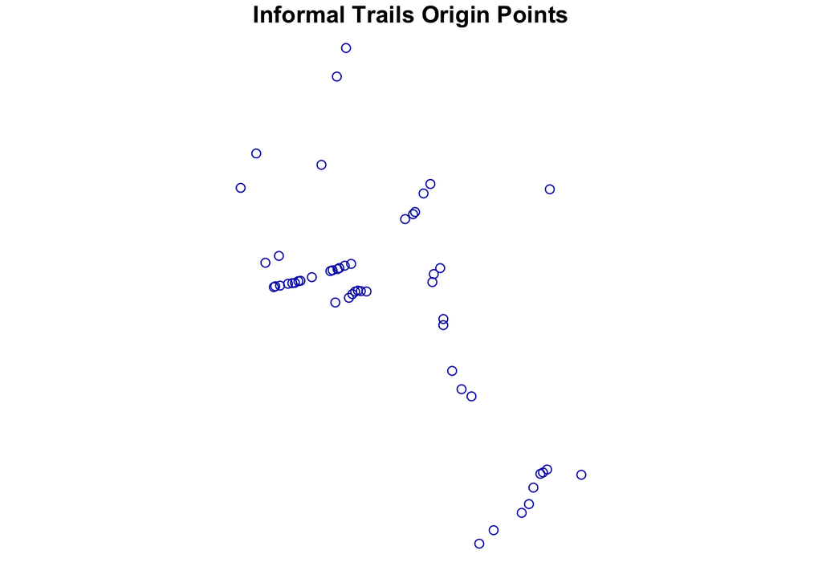

```r
#Subset to look at one set of points
InfTrails<-InfTrailsAll[,1]
#Visualize the data
plot(InfTrails, main="Informal Trails Origin Points")
```

```r
#Add a projection
InfTrails_proj <- st_transform(InfTrails, "+proj=utm +zone=11 +ellps=GRS80")
#convert to a planar point pattern (ppp) so spatstat can analyze the points
InfTrails.ppp <- as.ppp(InfTrails_proj)
```

## Analysis/processing & Checking Outcomes

In the context of informal trail origin points, I would probably expect a clustering pattern, because trails probably originate around a place of interest. I would be pretty surprised to see a regular distribution of origin points, because I can’t imagine what kind of underlying reason would cause trails to be less likely to start near other trails with enough regularity to make that happen. However, being able to screen for this could be useful later on, particularly with the milkvetch plants. Mulford’s milkvetch is not a good competitor, and it seems to thrive away from other plants. Checking to see what kind of distribution pattern the plants have, and at what scales they might be clustered or perhaps regularly spaced will be of interest. Eventually, I will hope to develop this code further to be able to identify the boundaries of clusters of points, probably using some kind of moving window analysis. I will check the outcomes of my analyses by plotting points to have a visual reference, as well as looking at the outputs (p values, etc) of the tests I run.

Quadrat test on simulated clustered data

```r
#Run a quadrat test, and set the alternative hypothesis to be that the points are clustered
quadrat.test(p_cluster, alternative = "clustered")
```

```
##
##  Chi-squared test of CSR using quadrat counts
##
## data:  p_cluster
## X2 = 53.387, df = 24, p-value = 0.0005142
## alternative hypothesis: clustered
##
## Quadrats: 25 tiles (irregular windows)
```

```r
#p value is <<.01, so we reject the null hypothesis and conclude the data shows evidence of clustering
```

Quadrat test on simulated regular data

```r
#Run a quadrat test, and set the alternative hypothesis to be that the points are regularly distributed
quadrat.test(p_regular, alternative = "regular")
```

```
##
##  Chi-squared test of CSR using quadrat counts
##
## data:  p_regular
## X2 = 8.57, df = 24, p-value = 0.001619
## alternative hypothesis: regular
##
## Quadrats: 25 tiles (irregular windows)
```

```r
# The p value is <.01, and there appears to be evidence of uniform spacing.
```

Quadrat test on sample data

```r
quadrat.test(InfTrails.ppp, alternative = "clustered")
```

```
##
##  Chi-squared test of CSR using quadrat counts
##
## data:  InfTrails.ppp
## X2 = 148.96, df = 24, p-value < 2.2e-16
## alternative hypothesis: clustered
##
## Quadrats: 5 by 5 grid of tiles
```

```r
#p values is <<.001; there's strong evidence for clustering in the data
quadrat.test(InfTrails.ppp, alternative = "regular")
```

```
##
##  Chi-squared test of CSR using quadrat counts
##
## data:  InfTrails.ppp
## X2 = 148.96, df = 24, p-value = 1
## alternative hypothesis: regular
##
## Quadrats: 5 by 5 grid of tiles
```

```r
#p value = 1; there doesn't appear to be evidence of regular spacing
```

Ripley’s K test on the clustered simulated data

```r
K_cluster_env.clustered <- envelope(p_cluster, Kest, correction = "border")
```

[output not shown]

Ripley’s K test on the regular simulated data

```r
K_cluster_env.regular <- envelope(p_regular, Kest, correction = "border")
```

[output not shown]

Ripley’s K test on the sample data

```r
K_cluster_env.sample <- envelope(InfTrails.ppp, Kest, correction = "border")
```

[output not shown]

## Packages

The main package I use for analysis in this project is spatstat. This is a basic spatial stats package with good documentation, and a focus on simulating and analyzing point patterns. A basic list of its functions and capabilities can be found here: https://spatstat.org/resources/spatstatQuickref.pdf

The other main package associated with the spatial analysis done here (mainly dealing with the sample data I brought in, and adding a projection to it) is sf. Sf is a workhorse spatial analysis package with extensive documentation. More information can be found about it here: https://www.rdocumentation.org/packages/sf/versions/0.9-2

## Benchmarking

The analyses I’m doing are pretty straightforward and not too data heavy on the points I’m using right now. But that may not always be the case. I’ll test using a Ripley’s K vs using a quadrat test to see if one is faster. These tests tell me slightly different things, but if one is way faster than the other and all I need to know is if something is clustered or not, that could be useful to know if I ever try to run these tests on a huge dataset.

It looks like the quadrat test can tell us whether clustering exists in the data considerably faster than the Ripley’s K.

```r
print(Ripley.time)
```

```
##    user  system elapsed
##   0.268   0.003   0.271
```

```r
print(Quadrat.time)
```

```
##    user  system elapsed
##   0.002   0.000   0.003
```

## Profiling

```r
rasterize.prof <- profvis(expr = {
  #load packages
  library(spatstat)
  library(sf)
  library(rgdal)
  library(rgeos)
  library(ggplot2)
  library(maptools)
  #Prep data
#Subset to look at one set of points
InfTrails<-InfTrailsAll[,1]
#Visualize the data
plot(InfTrails, main="Informal Trails Origin Points")

#Add a projection
InfTrails_proj <- st_transform(InfTrails, "+proj=utm +zone=11 +ellps=GRS80")
#convert to a planar point pattern (ppp) so spatstat can analyze the points
InfTrails.ppp <- as.ppp(InfTrails_proj)

#Run analysis
K_cluster_env <- envelope(InfTrails.ppp, Kest, correction = "border")
#plot analysis
plot(K_cluster_env, .-pi*r^2 ~ r)

}, interval = 0.01, prof_output = 'fstr-prof' )
```

From the results of the profiling I can see that the Ripley’s K test takes the most time and memory, and this is definitely a consideration for the future if I end up using it on a really large dataset.

```r
rasterize.prof
```

[output not shown]

## Final product

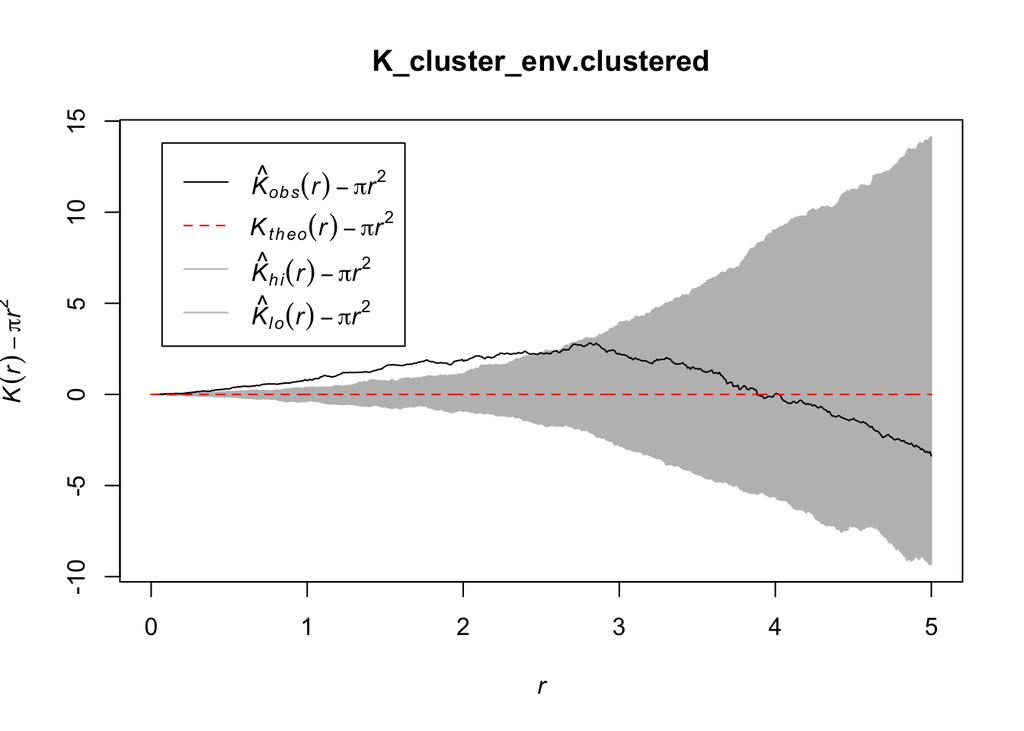

```r
plot1 <-plot(K_cluster_env.clustered, .-pi*r^2 ~ r)
```

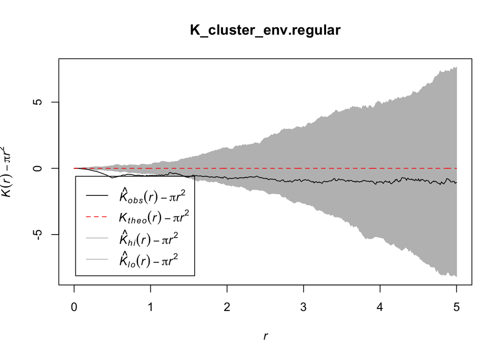

```r
plot2 <-plot(K_cluster_env.regular, .-pi*r^2 ~ r)
```

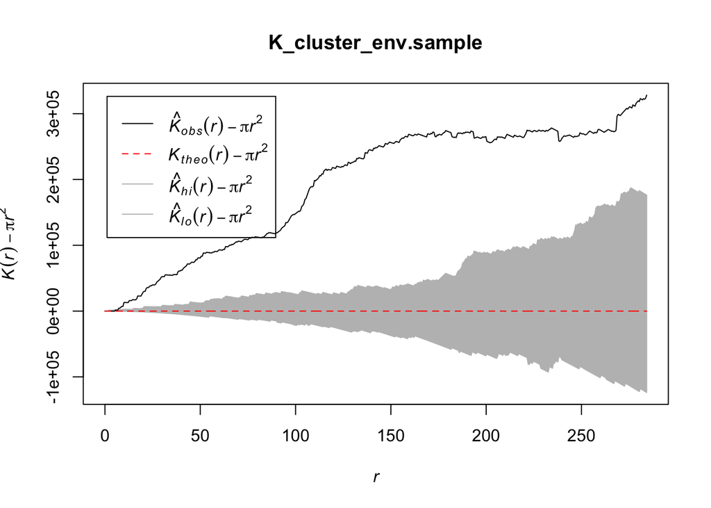

```r
plot3 <-plot(K_cluster_env.sample, .-pi*r^2 ~ r)
```

## Reflection

This was my first time trying any kind of spatial analysis in R, so I definitely learned quite a bit. As someone who has worked mostly with ESRI products, it was interesting to compare the strengths and weakenesses of the two platforms. R definitely has more flexibility, but some things that are quite simple in ArcMap, such as projections, were a little more challenging to wrangle in R. Using simulated data was a nice proof of concept for the clustering analysis tests, and learning to do benchmarking will be useful when I have to run analyses on larger datasets.